# Setting up large scale OSM environments for R using Osmosis and PostgreSQL with PostGIS

Konstantin Klemmer, Imperial College London

June 12, 2017

Importing **OpenStreetMap (OSM)** data into *R* can sometimes be rather difficult, especially when it comes to processing large datasets. There are some packages that aim at easy integration of OSM data, including the very versatile `osmar` package, that allows you to scrape data directly in *R* via the OSM API. Packages like `osmar`,`rgdal` or `sf` offer build-in functions to read spatial data formats that OSM data comes with.

However, these packages reach their limits when it comes to larger datasets and running the programmes on weak machines. I want to introduce an easy way to set up an environment to process large OSM datasets in R, using the *Java* application **Osmosis** and the open-source database **PostgreSQL** with the **PostGIS** extension for spatial data.

This tutorial was created using a **Asus Zenbook UX32LA** with a **i5-4200U CPU**, **8 GB RAM** and a **250 GB SSD**, running on Windows 10. The data used has a size of **1.9 GB** (unzipped). Under this setting, OSM data import using `osmar`, `rgdal` and `sf` takes up several hours, if not days, especially if you want to continue using your system. The following steps thus show a way to set up larger spatial data environments using the PostgreSQL database scheme and how to easily import this data into *R*.

## Getting OSM data

The place to extract large OSM datasets is the file dump **Planet.osm**, which can be found here: https://wiki.openstreetmap.org/wiki/Planet.osm

Here, we can download all available OSM data or search for extracts from our area of interest. I am interested in downloading the most recent OSM data for Greater London, which for instance is provided by **Geofabrik**. This archive offers OSM data for predefined layers like countries, states or urban areas. The London data that I will be using in this tutorial can be found here: http://download.geofabrik.de/europe/great-britain/england/greater-london.html

I download the file `greater-london-latest.osm.pbf`, conatining the complete dataset for the Greater London area. Note that this file is updated regularly.

## Setting up PostgreSQL and PostGIS

We now need to download and install **PostgreSQL** with the **PostGIS** extension. A detailed explanation on how to install PostgreSQL can be found here: https://wiki.postgresql.org/wiki/Detailed_installation_guides

Make sure you note `username`, `password` and the `port` you use for the installation. After PostgreSQL is installed on the system, PostGIS can be added as described here: https://wiki.openstreetmap.org/wiki/PostGIS/Installation

Now, open **pgAdmin** to set up your database. We can create new databases by clicking on `Object` – `Create` – `Database`, inserting a name of your choice, e.g. `London OSM`.

[figure not shown]

My new database `OSM London` is now in place and can be prepared for data import. We have to create two extensions to our database, using a `SQL` script. We navigate into the new database and open the script command line by clicking on `Object` – `CREATE Script` and execute two commands:

- `CREATE EXTENSION postgis;`
- `CREATE EXTENSION hstore;`

[figure not shown]

These extensions should now show up when openng the `Extensions` path in our `London OSM` database.

## Setting up Osmosis and importing the data

The tool connecting our dataset with PostgreSQL is called **Osmosis**. It is a command line Java application and can be used to read, write and manipulate OSM data. The latest stable version including detailed installation information for different OS can be found here: https://wiki.openstreetmap.org/wiki/Osmosis (Note that Osmosis requires the Java Runtime Environment, which can be downloaded at https://java.com/download/)

If you are using Windows, you can navigate into the Osmosis installation folder, e.g. `C:\Program Files (x86)\osmosis\bin\`, and open `osmosis.bat`. Double clicking this file opens the Osmosis command line. To keep the Osmosis window open, create a shortcut to the `osmosis.bat` file, open its properties and add `cmd /k` at the beginning of the target in the shortcut tab. The Osmosis output should look like this:

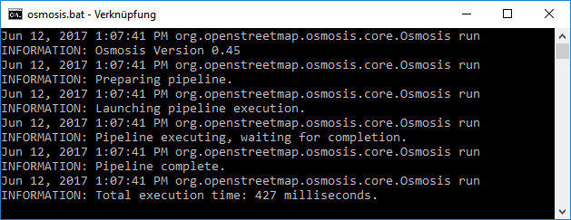

We now have to prepare our **PostgreSQL** database for the OSM data import (courtesy of Stackexchange user *zehpunktbarron*). Navigate back into **pgAdmin** and the `OSM London` database and create a new script via `Object` – `CREATE Script`. Now, execute the `SQL` code that you find in two of the files that you created when installing Osmosis. First execute the code from `[PATH_TO_OSMOSIS]\script\pgsnapshot_schema_0.6.sql` and afterwards the code from `[PATH_TO_OSMOSIS]\script\pgsnapshot_schema_0.6_linestring.sql`.

Now, add indices to the database to better process the data. Execute the following `SQL` commands in the script:

- `CREATE INDEX idx_nodes_tags ON nodes USING GIN(tags);`
- `CREATE INDEX idx_ways_tags ON ways USING GIN(tags);`
- `CREATE INDEX idx_relations_tags ON relations USING GIN(tags);`

We have now successfully prepared our database for the OSM import. Open **Osmosis** and run the following command to import the previously downloaded `.pbf` file:

`"[PATH_TO_OSMOSIS]\bin\osmosis" --read-pbf file="[PATH_TO_OSM_OSIS_FILE]\greater-london-latest.osm.pbf" --write-pgsql` `host="localhost" database="London OSM" user="YOUR_USERNAME" password="YOUR_PASSWORD"`

Note that if the `.pbf` file is larger, this process might take a while – also depending on the specs of your system. If the data import was successful, this should give you an output that looks like this:

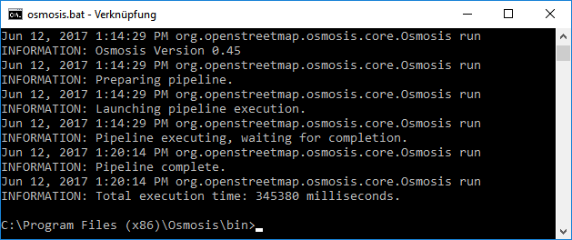

## Accessing PostgreSQL databases in R

Our freshly imported database is now ready to be accessed via *R*. Connecting to the PostgreSQL database requires the R package `RPostgreSQL`. First, we load the PostgreSQL driver and connect to the database using our credentials:

```r
require(RPostgreSQL)
# LOAD POSTGRESQL DRIVER
driver <- dbDriver("PostgreSQL")
# CREATE CONNECTION TO THE POSTGRESQL DATABASE
# THE CONNECTION VARIABLE WILL BE USED FOR ALL FURTHER OPERATIONS
connection <- dbConnect(driver, dbname = "London OSM",
                 host = "localhost", port = 5432,
                 user = "YOUR_USERNAME", password = "YOUR_PASSWORD")
```

We can now check, whether we have successfully established a connection to our database using a simple command:

```r
dbExistsTable(connection, "lines")
```

```
## [1] TRUE
```

We have now set up the environment to load OSM data into R flawlessly. Note that queries using `RPostgreSQL` are written in the `SQL` syntax. Further information on the use of the `RPostgreSQL` package can be found here: https://www.r-bloggers.com/using-postgresql-in-r-a-quick-how-to/

## Creating spatial data frames in R

In the last step of this tutorial we will explore how to put the accessed data to work and how to properly establish the geographical reference. We first load data into the *R* environment, using a `RPostgreSQL` query. The following query creates a `data.frame` with all available OSM point data. We use the PostGIS command `ST_AsText` on the `wkb_geometry` column to return the Well Known Text (WKT) geometries and save it in the newly created column `geom`. After that, we delete the now redundant `wkb_geometry` column.

```r
#LOAD POINT DATA FROM OSM DATABASE
points <- dbGetQuery(connection, "SELECT * , ST_AsText(wkb_geometry) AS geom from points")
points$wkb_geometry <- NULL
```

The `points` data frame contains all available OSM point data, including the several different tagging schemes, which can be further explored looking at OSMs’ map features: https://wiki.openstreetmap.org/wiki/Map_Features

```r
head(points)
```

```
##   ogc_fid osm_id                        name   barrier         highway
## 1       1      1 Prime Meridian of the World      <NA>            <NA>
## 2       2  99941                        <NA> lift_gate            <NA>
## 3       3 101831                        <NA>      <NA>        crossing
## 4       4 101833                        <NA>      <NA>        crossing
## 5       5 101839                        <NA>      <NA> traffic_signals
## 6       6 101843                        <NA>      <NA> traffic_signals
##    ref address is_in place man_made
## 1 <NA>    <NA>  <NA>  <NA>     <NA>
## 2 <NA>    <NA>  <NA>  <NA>     <NA>
## 3 <NA>    <NA>  <NA>  <NA>     <NA>
## 4 <NA>    <NA>  <NA>  <NA>     <NA>
## 5 <NA>    <NA>  <NA>  <NA>     <NA>
## 6 <NA>    <NA>  <NA>  <NA>     <NA>
##                                                other_tags
## 1              "historic"=>"memorial","memorial"=>"stone"
## 2                                                    <NA>
## 3 "crossing"=>"traffic_signals","crossing_ref"=>"pelican"
## 4                                    "crossing"=>"island"
## 5                                                    <NA>
## 6                                                    <NA>
##                           geom
## 1 POINT(-0.0014863 51.4779481)
## 2 POINT(-0.1553793 51.5231639)
## 3 POINT(-0.1470438 51.5356116)
## 4 POINT(-0.1588224 51.5350894)
## 5 POINT(-0.1526586 51.5375096)
## 6   POINT(-0.163653 51.534922)
```

Now, to get the geometry working, we can transform the data frame into a spatial data frame using the `sf` package (Note that I use the WGS84 as coordinate reference system):

```r
#SET COORDINATE SYSTEM
require(sf)
points <- st_as_sf(points, wkt="geom") %>% `st_crs<-`(4326)
```

We can now scrape our dataset for the data we are looking for, e.g. all bicycle parking spots (see https://wiki.openstreetmap.org/wiki/Tag:amenity%3Dbicycle_parking. Since `sf` data is stored in spatial data frames, we can easily create a subset containing our desired points - e.g. using the `filter` function from the `dplyr` package and `str_detect` from `stringr`:

```r
require(dplyr)
require(stringr)
#EXTRACTING ALL POINTS TAGGED 'BUS_STOP'
bikepark <- points %>% filter(str_detect(other_tags, "bicycle_parking"))
```

Additionall to all bike parking spots, we also want to include all explicitly marked bicycle routes, as found in the `lines` data. These can be extracted from OSM relation data via the `cycleway` tag: https://wiki.openstreetmap.org/wiki/Key:cycleway

We can contrast cycleways from the regular road network by also selecting the most common road type (see https://wiki.openstreetmap.org/wiki/Key:highway). Note that after our final `PostgreSQL` query, we close the connection using the `dbDisconnect` command.

```r
#LOAD RELATION DATA
lines <- dbGetQuery(connection, "SELECT * , ST_AsText(wkb_geometry) AS geom from lines")
lines$wkb_geometry <- NULL
dbDisconnect(connection)
```

```
## [1] TRUE
```

```r
#SET CRS
lines <- st_as_sf(lines, wkt="geom") %>% `st_crs<-`(4326)
#SUBSET CYCLEWAYS
cycleways <- lines %>% filter(highway=="cycleway")
#SUBSET OTHER STREETS
streets <- lines %>% filter(highway=="motorway" |
                            highway=="trunk" |
                            highway=="primary" |
                            highway=="secondary" |
                            highway=="tertiary")
```

Having created subsets for bicycle parking spots, cycleways and regular roads. We finally plot our data using `ggplot2` and the `geom_sf` function:

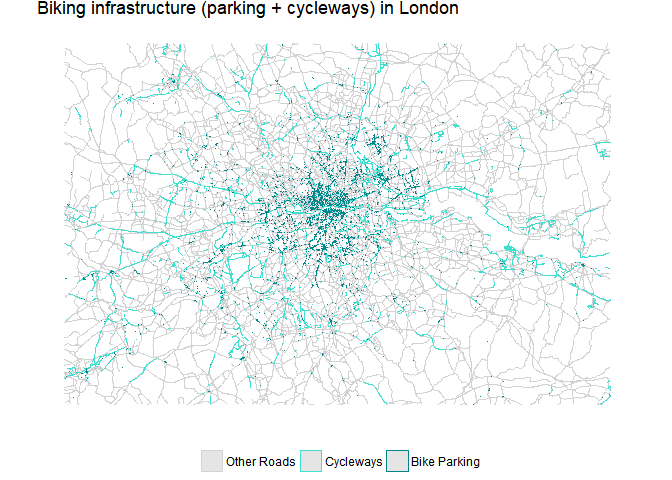

```r
require(ggplot2)
#PLOTTING ALL BUS STOPS
ggplot(bikepark) +
  geom_sf(data=streets,aes(colour="lightgrey")) + #Requires development version of ggplot2: devtools::install_github("tidyverse/ggplot2")
  geom_sf(data=cycleways,aes(colour="turquoise")) +
  geom_sf(data=bikepark,aes(colour="turquoise4"),shape=".") +
  coord_sf(crs = st_crs(bikepark)) +
  ggtitle("Biking infrastructure (parking + cycleways) in London") +
  scale_colour_manual("",values = c("lightgrey","turquoise","turquoise4"),labels=c("Other Roads","Cycleways","Bike Parking")) +
  theme_void() +
  theme(legend.position="bottom")
```